# NLP Week 5- Sentiment Analysis on Unabomber

### Justification

I used the cleaning genie to perform text cleaning, splitting, and tokenizing, as I am interested in looking at individual words and their associations as well as general, larger picture questions. By putting each individual word, in its most basic and dictionary-level form, in a row, I’m able to zoom out by data wrangling post-hoc, and zoom in on the already split, unlisted, tokenized, and lemmatized words.

I opted to look exclusively at the story data due to the conversational and creation aspects of it. When it comes to emotional language, this data will be much more interesting than the definitions.

I chose anger, anxiety, guilt, and sadness because they are words that *may* be elicited by a gaslighting experience, and are also negatively valenced. I find that I’m always more interested in how negatively a person feels; occupational hazard, I suppose.

I created averages of each emotion chosen so that I could get a zoomed out picture before diving into (spoiler!) exploratory analyses. I find that it’s always better to make the zoomed-out association before zooming back in, and my hypothesis allows that to happen.

## Analyze Data

### Statistics

```r
# anger
anger <- lm(anger_avg ~ Gender, data = combined)
summary(anger)
```

```
##
## Call:
## lm(formula = anger_avg ~ Gender, data = combined)
##
## Residuals:
##      Min       1Q   Median       3Q      Max
## -0.65298 -0.09040 -0.00297  0.07909  1.06458
##
## Coefficients:
##              Estimate Std. Error  t value Pr(>|t|)
## (Intercept)  2.341800   0.001179 1985.636  < 2e-16 ***
## GenderFemale 0.004527   0.001309    3.459 0.000542 ***
## ---
## Signif. codes:  0 '***' 0.001 '**' 0.01 '*' 0.05 '.' 0.1 ' ' 1
##
## Residual standard error: 0.1468 on 82488 degrees of freedom
##   (8 observations deleted due to missingness)
## Multiple R-squared:  0.000145,   Adjusted R-squared:  0.0001329
## F-statistic: 11.97 on 1 and 82488 DF,  p-value: 0.0005423
```

```r
# guilt
guilt <- lm(guilt_avg ~ Gender, data = combined)
summary(guilt)
```

```
##
## Call:
## lm(formula = guilt_avg ~ Gender, data = combined)
##
## Residuals:
##      Min       1Q   Median       3Q      Max
## -0.52418 -0.09949 -0.01409  0.07787  1.08123
##
## Coefficients:
##              Estimate Std. Error t value Pr(>|t|)
## (Intercept)  2.434630   0.001292 1885.07  < 2e-16 ***
## GenderFemale 0.004113   0.001433    2.87  0.00411 **
## ---
## Signif. codes:  0 '***' 0.001 '**' 0.01 '*' 0.05 '.' 0.1 ' ' 1
##
## Residual standard error: 0.1608 on 82488 degrees of freedom
##   (8 observations deleted due to missingness)
## Multiple R-squared:  9.985e-05,  Adjusted R-squared:  8.773e-05
## F-statistic: 8.237 on 1 and 82488 DF,  p-value: 0.004105
```

```r
# anxiety
anxiety <- lm(anxiety_avg ~ Gender, data = combined)
summary(anxiety)
```

```
##
## Call:
## lm(formula = anxiety_avg ~ Gender, data = combined)
##
## Residuals:
##      Min       1Q   Median       3Q      Max
## -0.46572 -0.07306 -0.00321  0.07789  0.79405
##
## Coefficients:
##              Estimate Std. Error t value Pr(>|t|)
## (Intercept)  2.407819   0.001017 2367.56   <2e-16 ***
## GenderFemale 0.026383   0.001129   23.38   <2e-16 ***
## ---
## Signif. codes:  0 '***' 0.001 '**' 0.01 '*' 0.05 '.' 0.1 ' ' 1
##
## Residual standard error: 0.1266 on 82488 degrees of freedom
##   (8 observations deleted due to missingness)
## Multiple R-squared:  0.006582,   Adjusted R-squared:  0.00657
## F-statistic: 546.5 on 1 and 82488 DF,  p-value: < 2.2e-16
```

```r
# sadness
sadness <- lm(sad_avg ~ Gender, data = combined)
summary(sadness)
```

```
##
## Call:
## lm(formula = sad_avg ~ Gender, data = combined)
##
## Residuals:
##      Min       1Q   Median       3Q      Max
## -0.65559 -0.08137  0.00021  0.08140  0.90083
##
## Coefficients:
##              Estimate Std. Error t value Pr(>|t|)
## (Intercept)  2.251699   0.001082 2080.16   <2e-16 ***
## GenderFemale 0.019075   0.001201   15.88   <2e-16 ***
## ---
## Signif. codes:  0 '***' 0.001 '**' 0.01 '*' 0.05 '.' 0.1 ' ' 1
##
## Residual standard error: 0.1348 on 82488 degrees of freedom
##   (8 observations deleted due to missingness)
## Multiple R-squared:  0.003048,   Adjusted R-squared:  0.003036
## F-statistic: 252.2 on 1 and 82488 DF,  p-value: < 2.2e-16
```

### Visualizations

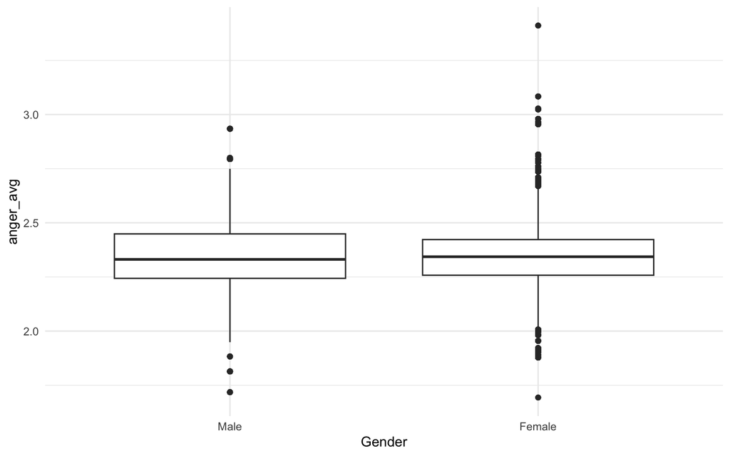

```r
# anger
ggplot(combined, aes(x = Gender, y = anger_avg)) + geom_boxplot() + theme_minimal()
```

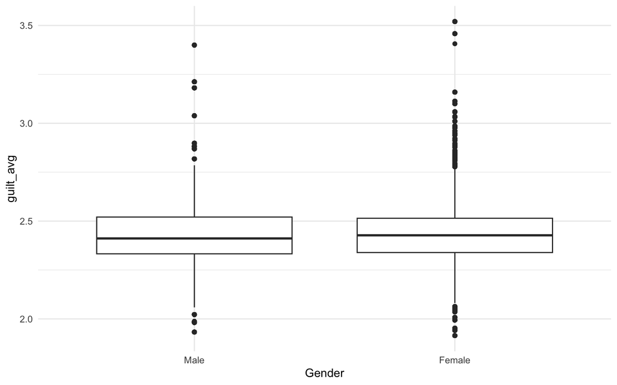

```r
# guilt
ggplot(combined, aes(x = Gender, y = guilt_avg)) + geom_boxplot() + theme_minimal()
```

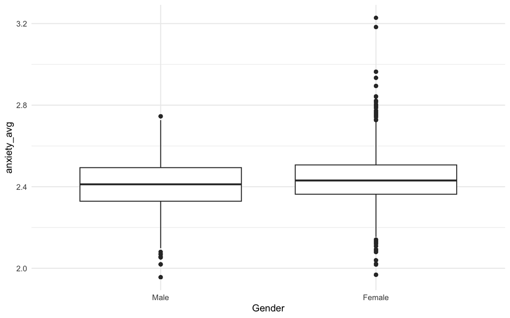

```r
# anxiety
ggplot(combined, aes(x = Gender, y = anxiety_avg)) + geom_boxplot() + theme_minimal()
```

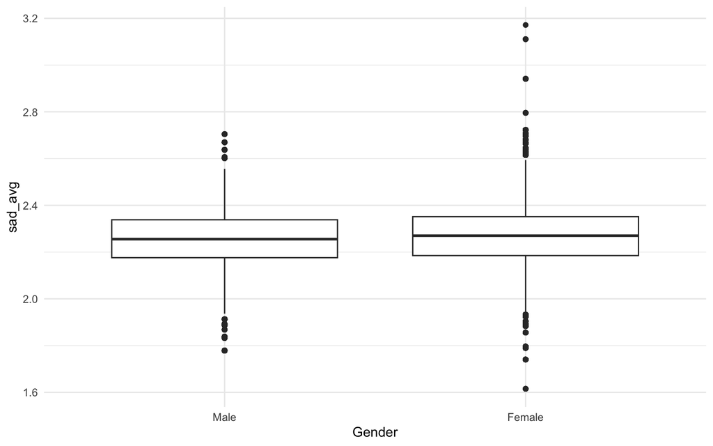

```r
# sadness
ggplot(combined, aes(x = Gender, y = sad_avg)) + geom_boxplot() + theme_minimal()
```

## Exploratory Analyses!

### Hypothesis

Screw it, I’m doing some exploratory analyses! I can see that women-identifying participants are, on average, using more negatively valenced words in general when telling their stories. I’m interested in whether that trend is moderated by “time”, in that there will be differences in gender identity on when–in the story–valenced words are used.

### Data Prep

```r
# creating 'time' variable (essentially word count, but to serve as a time
# anchor for each participant)
combined_explor <- combined |>
    group_by(ID) |>
    mutate(time = row_number(), time_c = scale(time, scale = F), word_count = n()) |>
    ungroup()
```

### Statistics

```r
exp_anger <- lmer(emo_anger_rescale ~ Gender * time_c + word_count + (1 | ID), data = combined_explor)  # controlling for word count
summary(exp_anger)
```

```
## Linear mixed model fit by REML. t-tests use Satterthwaite's method [
## lmerModLmerTest]
## Formula: emo_anger_rescale ~ Gender * time_c + word_count + (1 | ID)
##    Data: combined_explor
##
## REML criterion at convergence: 95665.8
##
## Scaled residuals:
##     Min      1Q  Median      3Q     Max
## -3.1419 -0.4746 -0.0500  0.5120  8.3458
##
## Random effects:
##  Groups   Name        Variance Std.Dev.
##  ID       (Intercept) 0.008887 0.09427
##  Residual             0.532128 0.72947
## Number of obs: 43089, groups:  ID, 1007
##
## Fixed effects:
##                       Estimate Std. Error         df t value Pr(>|t|)
## (Intercept)          2.359e+00  1.312e-02  7.801e+02 179.805  < 2e-16 ***
## GenderFemale         1.012e-03  1.233e-02  8.158e+02   0.082  0.93463
## time_c               6.578e-04  1.756e-04  4.223e+04   3.746  0.00018 ***
## word_count          -1.154e-04  6.984e-05  3.741e+02  -1.652  0.09941 .
## GenderFemale:time_c -7.590e-05  1.966e-04  4.224e+04  -0.386  0.69948
## ---
## Signif. codes:  0 '***' 0.001 '**' 0.01 '*' 0.05 '.' 0.1 ' ' 1
##
## Correlation of Fixed Effects:
##             (Intr) GndrFm time_c wrd_cn
## GenderFemal -0.758
## time_c       0.004 -0.007
## word_count  -0.533 -0.008  0.005
## GndrFml:tm_ -0.005  0.008 -0.893 -0.002
```

```r
exp_guilt <- lmer(emo_guilt_rescale ~ Gender * time_c + word_count + (1 | ID), data = combined_explor)  # controlling for word count
summary(exp_guilt)
```

```
## Linear mixed model fit by REML. t-tests use Satterthwaite's method [
## lmerModLmerTest]
## Formula: emo_guilt_rescale ~ Gender * time_c + word_count + (1 | ID)
##    Data: combined_explor
##
## REML criterion at convergence: 101897.8
##
## Scaled residuals:
##     Min      1Q  Median      3Q     Max
## -2.8523 -0.6010 -0.0496  0.4022  8.3356
##
## Random effects:
##  Groups   Name        Variance Std.Dev.
##  ID       (Intercept) 0.01073  0.1036
##  Residual             0.61470  0.7840
## Number of obs: 43089, groups:  ID, 1007
##
## Fixed effects:
##                       Estimate Std. Error         df t value Pr(>|t|)
## (Intercept)          2.461e+00  1.424e-02  7.441e+02 172.808   <2e-16 ***
## GenderFemale         2.144e-03  1.338e-02  7.759e+02   0.160   0.8727
## time_c               1.795e-03  1.888e-04  4.218e+04   9.511   <2e-16 ***
## word_count          -1.997e-04  7.613e-05  3.626e+02  -2.622   0.0091 **
## GenderFemale:time_c -2.827e-04  2.113e-04  4.218e+04  -1.338   0.1810
## ---
## Signif. codes:  0 '***' 0.001 '**' 0.01 '*' 0.05 '.' 0.1 ' ' 1
##
## Correlation of Fixed Effects:
##             (Intr) GndrFm time_c wrd_cn
## GenderFemal -0.757
## time_c       0.004 -0.007
## word_count  -0.534 -0.008  0.005
## GndrFml:tm_ -0.005  0.008 -0.893 -0.002
```

```r
exp_anxiety <- lmer(emo_anxiety_rescale ~ Gender * time_c + word_count + (1 | ID),
    data = combined_explor)  # controlling for word count
summary(exp_anxiety)
```

```
## Linear mixed model fit by REML. t-tests use Satterthwaite's method [
## lmerModLmerTest]
## Formula: emo_anxiety_rescale ~ Gender * time_c + word_count + (1 | ID)
##    Data: combined_explor
##
## REML criterion at convergence: 85626.3
##
## Scaled residuals:
##     Min      1Q  Median      3Q     Max
## -3.5917 -0.5335  0.0608  0.4742 10.1561
##
## Random effects:
##  Groups   Name        Variance Std.Dev.
##  ID       (Intercept) 0.006429 0.08018
##  Residual             0.421850 0.64950
## Number of obs: 43089, groups:  ID, 1007
##
## Fixed effects:
##                       Estimate Std. Error         df t value Pr(>|t|)
## (Intercept)          2.418e+00  1.146e-02  8.250e+02 211.043  < 2e-16 ***
## GenderFemale         2.668e-02  1.077e-02  8.682e+02   2.478   0.0134 *
## time_c               7.281e-04  1.564e-04  4.230e+04   4.657 3.22e-06 ***
## word_count          -7.825e-05  6.043e-05  3.824e+02  -1.295   0.1961
## GenderFemale:time_c -1.032e-04  1.751e-04  4.231e+04  -0.589   0.5557
## ---
## Signif. codes:  0 '***' 0.001 '**' 0.01 '*' 0.05 '.' 0.1 ' ' 1
##
## Correlation of Fixed Effects:
##             (Intr) GndrFm time_c wrd_cn
## GenderFemal -0.758
## time_c       0.004 -0.008
## word_count  -0.533 -0.007  0.006
## GndrFml:tm_ -0.005  0.009 -0.893 -0.002
```

```r
exp_sadness <- lmer(emo_sadness_rescale ~ Gender * time_c + word_count + (1 | ID),
    data = combined_explor)  # controlling for word count
summary(exp_sadness)
```

```
## Linear mixed model fit by REML. t-tests use Satterthwaite's method [
## lmerModLmerTest]
## Formula: emo_sadness_rescale ~ Gender * time_c + word_count + (1 | ID)
##    Data: combined_explor
##
## REML criterion at convergence: 95116.9
##
## Scaled residuals:
##     Min      1Q  Median      3Q     Max
## -3.2487 -0.5781 -0.0148  0.5539  7.8074
##
## Random effects:
##  Groups   Name        Variance Std.Dev.
##  ID       (Intercept) 0.005764 0.07592
##  Residual             0.527125 0.72603
## Number of obs: 43089, groups:  ID, 1007
##
## Fixed effects:
##                       Estimate Std. Error         df t value Pr(>|t|)
## (Intercept)          2.236e+00  1.200e-02  7.775e+02 186.222  < 2e-16 ***
## GenderFemale         1.633e-02  1.131e-02  8.378e+02   1.444   0.1490
## time_c               1.090e-03  1.748e-04  4.235e+04   6.237  4.5e-10 ***
## word_count           1.491e-04  6.126e-05  3.168e+02   2.434   0.0155 *
## GenderFemale:time_c -2.455e-05  1.957e-04  4.236e+04  -0.125   0.9002
## ---
## Signif. codes:  0 '***' 0.001 '**' 0.01 '*' 0.05 '.' 0.1 ' ' 1
##
## Correlation of Fixed Effects:
##             (Intr) GndrFm time_c wrd_cn
## GenderFemal -0.760
## time_c       0.005 -0.009
## word_count  -0.530 -0.006  0.006
## GndrFml:tm_ -0.006  0.010 -0.893 -0.002
```

### Visualization

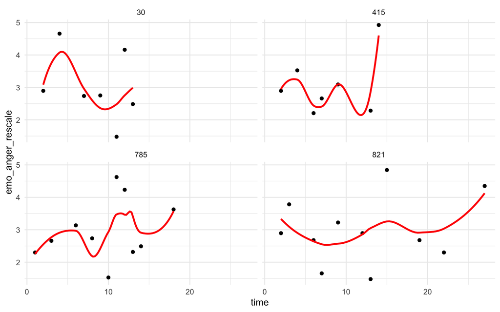

```r
# since these are exploratory, I took some liberties with the visualization. I
# was interested in the trajectories of individual participants as they spoke,
# but have moderation statistics to help build my argument, despite no
# significant interactions.

# this graph highlights the top 4 'angry' participants (on average)
angry_ps <- combined_explor |>
    filter(ID %in% c("415", "30", "821", "785"))  # all participants are female

ggplot(angry_ps, aes(x = time, y = emo_anger_rescale)) + geom_point() + geom_smooth(se = F,
    color = "red") + facet_wrap(~ID) + theme_minimal()
```

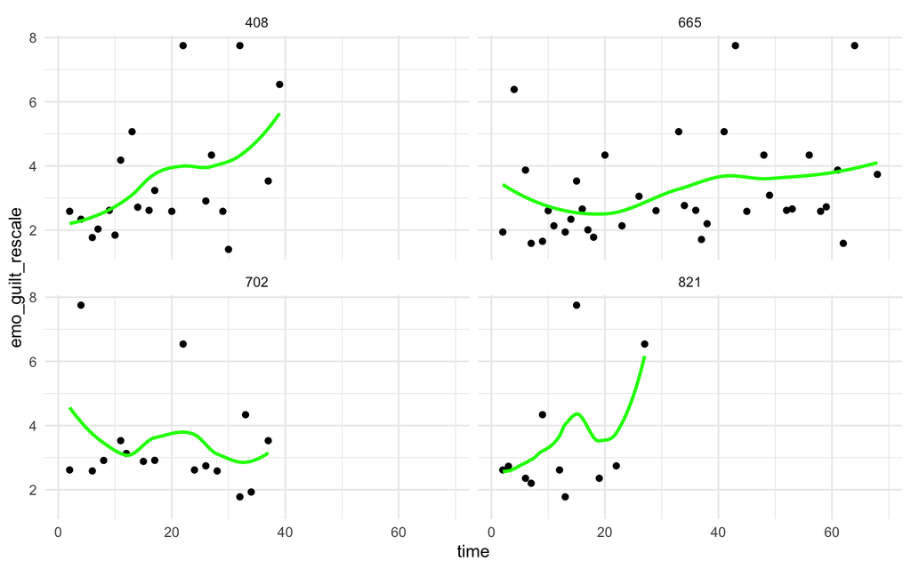

```r
# this graph highlights the top 4 'guilty' participants (on average)
guilt_ps <- combined_explor |>
    filter(ID %in% c("408", "821", "702", "665"))  # 408 & 821 are female; 702 & 665 are male

ggplot(guilt_ps, aes(x = time, y = emo_guilt_rescale)) + geom_point() + geom_smooth(se = F,
    color = "green") + facet_wrap(~ID) + theme_minimal()
```

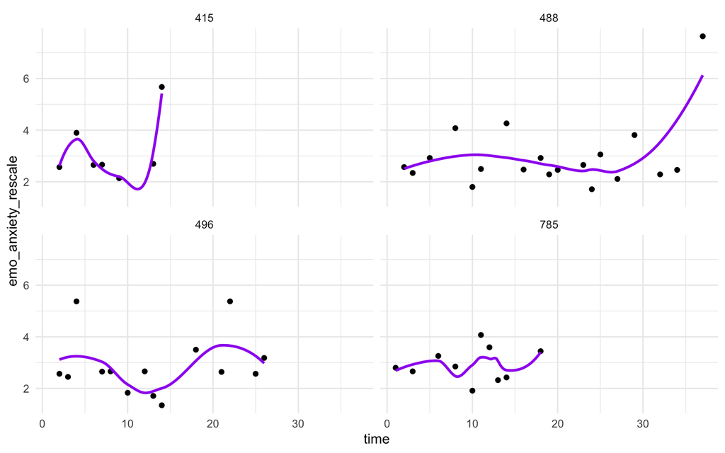

```r
# this graph highlights the top 4 'anxious' participants (on average)
anx_ps <- combined_explor |>
    filter(ID %in% c("415", "488", "785", "496"))  # all participants are female

ggplot(anx_ps, aes(x = time, y = emo_anxiety_rescale)) + geom_point() + geom_smooth(se = F,
    color = "purple") + facet_wrap(~ID) + theme_minimal()
```

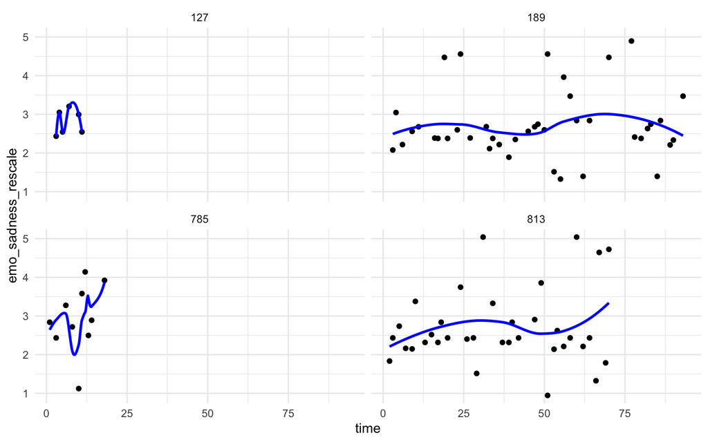

```r
# this graph highlights the top 4 'sad' participants (on average)
sad_ps <- combined_explor |>
    filter(ID %in% c("785", "127", "189", "813"))  # all participants are female

ggplot(sad_ps, aes(x = time, y = emo_sadness_rescale)) + geom_point() + geom_smooth(se = F,
    color = "blue") + facet_wrap(~ID) + theme_minimal()
```

## Written Report

Overall, there seems to be a gender difference in the averaged usage of select negatively valenced emotion words in a story on gaslighting, where women, on average, use words higher in anger (b = 0.005, SE = 0.001, *t* = 3.459, *p* < 0.001), higher in guilt (b = 0.004, SE = 0.001, *t* = 2.87, *p* = 0.004), higher in anxiety (b = 0.027, SE = 0.001, *t* = 23.38, *p* < 0.001), and higher in sadness (b = 0.019, SE = 0.001, *t* = 15.88, *p* < 0.001). While this does not fully match the original hypothesis, it does confirm half (women do, on average, use words that are considered anxious and sad). These results that women will, on average, use more negatively valenced words than men when describing a story with themes of gaslighting.

As for the exploratory results, we do not see a significant interaction effect between gender and time, suggesting that the trajectory of negatively valenced emotions over the time of telling a gaslighting story does not significantly differ by gender (anger: b < 0.001, SE < 0.001, *t* = 0.386, *p* = 0.6995; guilt: b < 0.001, SE < 0.001, *t* = 1.338, *p* = 0.1810; anxiety: b < 0.001, SE < 0.001, *t* = 0.589, *p* = 0.5557; sadness: b < 0.001, SE < 0.001, *t* = 0.125, *p* = 0.9002). These results do not support the exploratory hypothesis that time moderated the established relationships between gender and the selected negatively valenced emotions, and suggest that there may be additional underlying linguistic components that could further parse out the relationship between gender and negative valence word usage. I would be interested to see if this would hold for *all* of the negative emotions in the Lookup database, and I would also like to see if concreteness or semantic visualization may explain more of why women seem to use more negatively valenced emotion words.